# Breast Cancer dataset

### Breast cancer dataset

The following notebook is an exploration of the Breast Cancer Dataset downloaded from https://www.kaggle.com/uciml/breast-cancer-wisconsin-data.  
The aim is to predict the diagnosis, based on the features provided. The notebook attempts to explore the data and test four models against each other on which could be a potential candidate for predictions, as well as do a forward selection of features.

```python
from sklearn.decomposition import PCA
import pandas as pd
from sklearn.ensemble import RandomForestClassifier, GradientBoostingClassifier
from sklearn.linear_model import LogisticRegression
from sklearn.svm import SVC
from sklearn.model_selection import train_test_split
from sklearn.metrics import accuracy_score, plot_roc_curve, plot_confusion_matrix,confusion_matrix, plot_precision_recall_curve, precision_recall_fscore_support, roc_auc_score,auc
import matplotlib.pyplot as plt
import seaborn as sns
from sklearn.model_selection import cross_validate, KFold
```

```python
import warnings
warnings.filterwarnings('ignore')
```

```python
df = pd.read_csv('./data/data.csv')
```

```python
df.info()
```

```
<class 'pandas.core.frame.DataFrame'>
RangeIndex: 569 entries, 0 to 568
Data columns (total 32 columns):
 #   Column                   Non-Null Count  Dtype
---  ------                   --------------  -----
 0   id                       569 non-null    int64
 1   diagnosis                569 non-null    object
 2   radius_mean              569 non-null    float64
 3   texture_mean             569 non-null    float64
 4   perimeter_mean           569 non-null    float64
 5   area_mean                569 non-null    float64
 6   smoothness_mean          569 non-null    float64
 7   compactness_mean         569 non-null    float64
 8   concavity_mean           569 non-null    float64
 9   concave points_mean      569 non-null    float64
```

[output cut: 24 more lines]

we know that we have to predict a categorical variable from only numeric ones.

```python
df.head()
```

|  | id | diagnosis | radius_mean | texture_mean | perimeter_mean | area_mean | smoothness_mean | compactness_mean | concavity_mean | concave points_mean | ... | radius_worst | texture_worst | perimeter_worst | area_worst | smoothness_worst | compactness_worst | concavity_worst | concave points_worst | symmetry_worst | fractal_dimension_worst |
| --- | --- | --- | --- | --- | --- | --- | --- | --- | --- | --- | --- | --- | --- | --- | --- | --- | --- | --- | --- | --- | --- |
| 0 | 842302 | M | 17.99 | 10.38 | 122.80 | 1001.0 | 0.11840 | 0.27760 | 0.3001 | 0.14710 | ... | 25.38 | 17.33 | 184.60 | 2019.0 | 0.1622 | 0.6656 | 0.7119 | 0.2654 | 0.4601 | 0.11890 |
| 1 | 842517 | M | 20.57 | 17.77 | 132.90 | 1326.0 | 0.08474 | 0.07864 | 0.0869 | 0.07017 | ... | 24.99 | 23.41 | 158.80 | 1956.0 | 0.1238 | 0.1866 | 0.2416 | 0.1860 | 0.2750 | 0.08902 |
| 2 | 84300903 | M | 19.69 | 21.25 | 130.00 | 1203.0 | 0.10960 | 0.15990 | 0.1974 | 0.12790 | ... | 23.57 | 25.53 | 152.50 | 1709.0 | 0.1444 | 0.4245 | 0.4504 | 0.2430 | 0.3613 | 0.08758 |
| 3 | 84348301 | M | 11.42 | 20.38 | 77.58 | 386.1 | 0.14250 | 0.28390 | 0.2414 | 0.10520 | ... | 14.91 | 26.50 | 98.87 | 567.7 | 0.2098 | 0.8663 | 0.6869 | 0.2575 | 0.6638 | 0.17300 |
| 4 | 84358402 | M | 20.29 | 14.34 | 135.10 | 1297.0 | 0.10030 | 0.13280 | 0.1980 | 0.10430 | ... | 22.54 | 16.67 | 152.20 | 1575.0 | 0.1374 | 0.2050 | 0.4000 | 0.1625 | 0.2364 | 0.07678 |

5 rows × 32 columns

```python
df.isna().sum()
```

```
id                         0
diagnosis                  0
radius_mean                0
texture_mean               0
perimeter_mean             0
area_mean                  0
smoothness_mean            0
compactness_mean           0
concavity_mean             0
concave points_mean        0
symmetry_mean              0
fractal_dimension_mean     0
radius_se                  0
texture_se                 0
perimeter_se               0
area_se                    0
smoothness_se              0
compactness_se             0
concavity_se               0
concave points_se          0
symmetry_se                0
fractal_dimension_se       0
radius_worst               0
texture_worst              0
perimeter_worst            0
area_worst                 0
smoothness_worst           0
compactness_worst          0
concavity_worst            0
concave points_worst       0
symmetry_worst             0
fractal_dimension_worst    0
dtype: int64
```

The dataset is fully complete and does not require any cleaning, yay!!

```python
df['id'].apply(str).describe()
```

```
count        569
unique       569
top       908445
freq           1
Name: id, dtype: object
```

Each id is unique.

```python
df.drop('id', axis = 1, inplace = True)
```

Defining the target variable

```python
target = 'diagnosis'
```

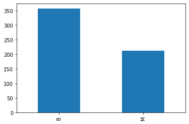

```python
df[target].value_counts().plot(kind='bar')
```

removing the target feature and describing the rest

```python
features = df.columns.to_list()
features.pop(features.index(target))
```

```
'diagnosis'
```

```python
len(features)
```

```
30
```

### data exploration

First, let's do some descriptive statistics for the different features.

```python
for feature in features:
    print(f'***\n{feature}\n***')
    print(df[feature].describe(), '\n')
```

```
***
radius_mean
***
count    569.000000
mean      14.127292
std        3.524049
min        6.981000
25%       11.700000
50%       13.370000
75%       15.780000
max       28.110000
Name: radius_mean, dtype: float64

***
texture_mean
***
count    569.000000
mean      19.289649
std        4.301036
min        9.710000
25%       16.170000
50%       18.840000
75%       21.800000
max       39.280000
Name: texture_mean, dtype: float64

***
perimeter_mean
***
count    569.000000
mean      91.969033
std       24.298981
min       43.790000
25%       75.170000
50%       86.240000
75%      104.100000
max      188.500000
Name: perimeter_mean, dtype: float64

***
```

[output cut: 334 more lines]

```
max        0.663800
Name: symmetry_worst, dtype: float64

***
fractal_dimension_worst
***
count    569.000000
mean       0.083946
std        0.018061
min        0.055040
25%        0.071460
50%        0.080040
75%        0.092080
max        0.207500
Name: fractal_dimension_worst, dtype: float64
```

Let's continue with some boxplots to explore the data

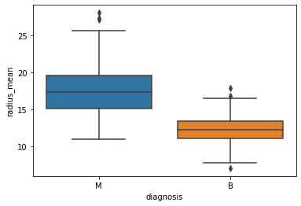

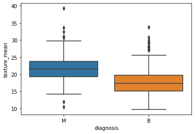

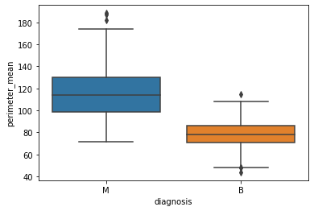

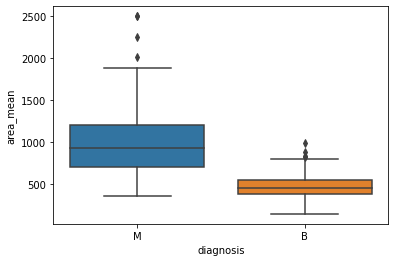

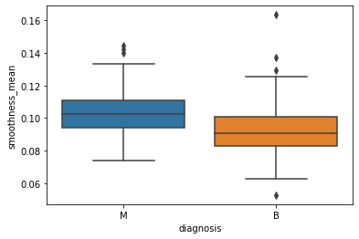

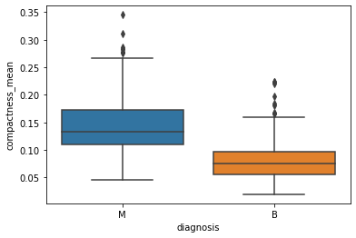

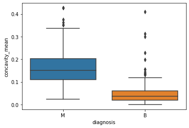

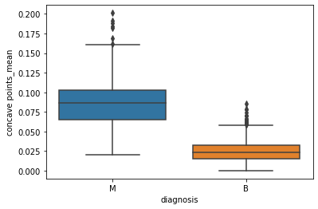

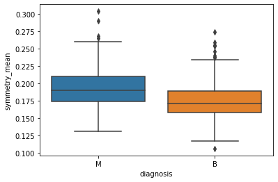

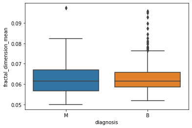

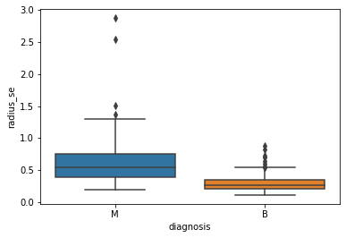

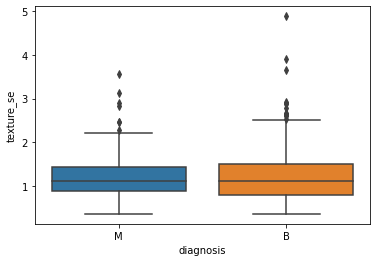

[18 more figures not shown]

```python
for feature in features:
    sns.boxplot(data=df, x=target, y=feature)
    plt.figure()
```

The following distribution plots showcase the same information, but present it differently.

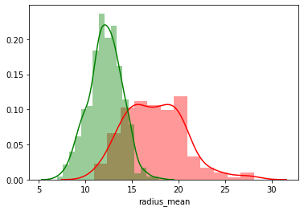

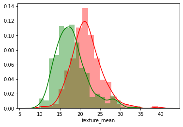

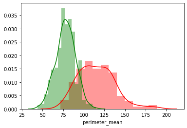

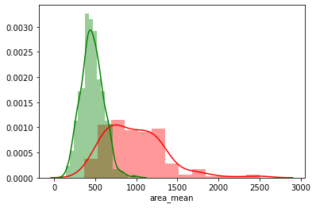

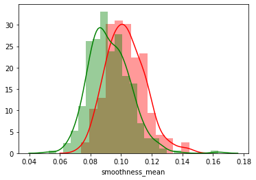

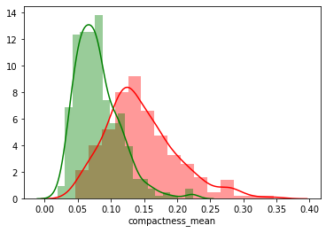

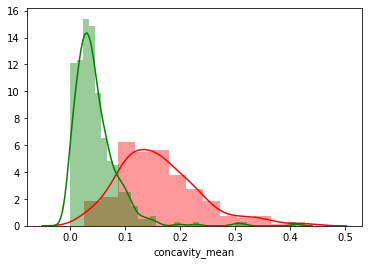

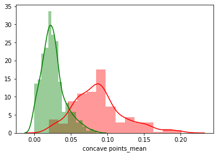

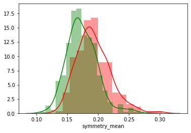

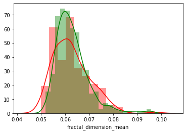

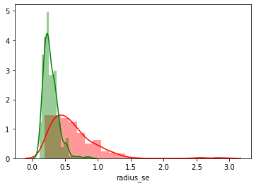

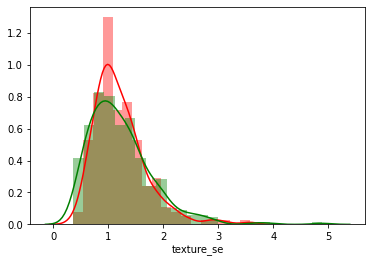

[18 more figures not shown]

```python
for feature in features:
    sns.distplot(df[df[target] == 'M'][feature], color='r')
    sns.distplot(df[df[target] == 'B'][feature], color='g')
    plt.figure()
```

From the above boxplots and distribution plots it is apparent that benevolent tumors are smaller in area, radius and perimeter. When looking at the features raidus_mean, concavity_mean and concave points_mean could provide to be good predictors. Let's have a look at a correlation matrix to see which features are in deed highly correllated with the outcome. As it is a binary outcome, let's map `benign` to 0 and `malevolent` to 1.

### Start modelling

#### first do feature selection based on forward selection method with 4 models

```python
# now as ou know our diagnosis column is a object type so we can map it to integer value
df[target] = df[target].map({'M': 1, 'B': 0})
```

do a correlation matrix

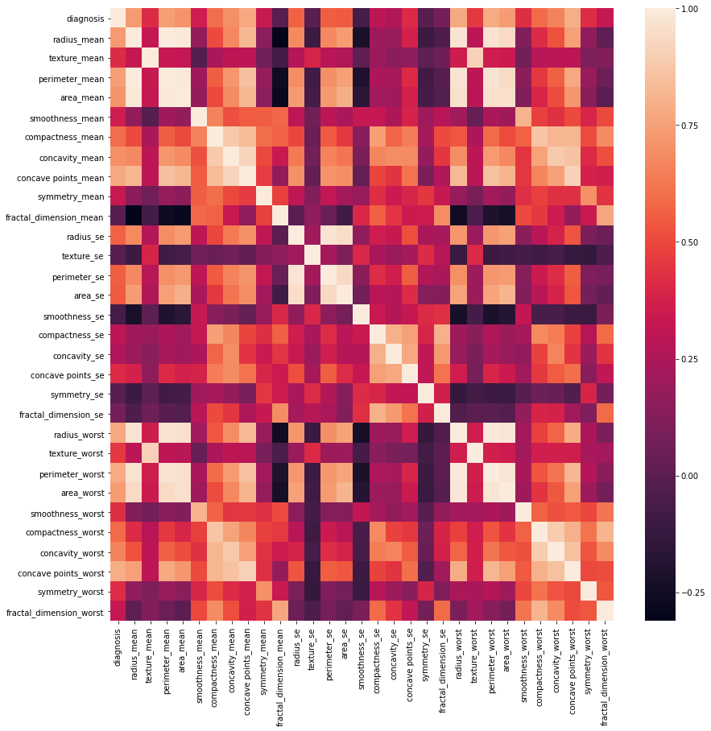

```python
plt.subplots(figsize=(14,14))
sns.heatmap(df.corr())
```

Based on the correlation values with the `diagnosis`, I'll order the columns by their correlation coefficient and use forward selection to determine which of the columns are relevant for making a good prediction

```python
correldf = df.corr()
correldf.iloc[0,:].sort_values(ascending = False)[1:]
feature_list = correldf.iloc[0, :].sort_values(ascending=False)[1:].index
```

In the below cell, I am defining four different models, each of which will be fitted with the forward selection model, and then scored accordingly.

```python
models = {
    'logistic_regression': LogisticRegression(),
    'svc': SVC(gamma='auto'),
    'random_forest': RandomForestClassifier(n_estimators=100),
    'gradient_boost': GradientBoostingClassifier()
}
```

```python
def evaluate_models(models: dict, df:pd.core.frame.DataFrame = df, target:str = 'diagnosis', feature_list : list = feature_list):
    """
    disclaimer: added default arguments so that this can be reused later, but added default values, so the code won't break.
    """

    model_performance = pd.DataFrame({'colnames': []})
    cv = KFold(5)
    scorers = ['accuracy', 'roc_auc', 'precision', 'recall']
    for name, model in models.items():
        relevant_cols = []
        for feature in feature_list:
            relevant_cols.append(feature)
            X = df[relevant_cols]
            y = df[target]

            x_df = pd.DataFrame(cross_validate(model, X, y, cv=cv,
                                            scoring=scorers, return_estimator=False))
            columns_string = ','.join(relevant_cols)
            performance_results = pd.DataFrame(
                {'colnames': [columns_string], 'model': name, 'accuracy': x_df['test_accuracy'].mean(), 'precision': x_df['test_precision'].mean(), 'recall': x_df['test_recall'].mean()})
            # test_roc_auc	test_precision	test_recall

            model_performance = model_performance.append(performance_results)

    return model_performance
```

```python
model_performance = evaluate_models(models)
model_performance.reset_index(inplace=True, drop=True)
model_performance['length'] = model_performance.colnames.apply(
    lambda x: len(x.split(',')))
model_performance['accuracy'] = model_performance.accuracy.apply(
    lambda x: round(x, 2))
```

Let's have a look at the best performing 15 models.

```python
model_performance.sort_values(
    ['accuracy', 'length'], ascending=[False, True]).head(15)
```

|  | colnames | model | accuracy | precision | recall | length |
| --- | --- | --- | --- | --- | --- | --- |
| 107 | concave points_worst,perimeter_worst,concave p... | gradient_boost | 0.96 | 0.946343 | 0.942233 | 18 |
| 78 | concave points_worst,perimeter_worst,concave p... | random_forest | 0.96 | 0.960255 | 0.942491 | 19 |
| 79 | concave points_worst,perimeter_worst,concave p... | random_forest | 0.96 | 0.956921 | 0.939550 | 20 |
| 80 | concave points_worst,perimeter_worst,concave p... | random_forest | 0.96 | 0.950627 | 0.942491 | 21 |
| 110 | concave points_worst,perimeter_worst,concave p... | gradient_boost | 0.96 | 0.957222 | 0.936351 | 21 |
| 81 | concave points_worst,perimeter_worst,concave p... | random_forest | 0.96 | 0.947644 | 0.937491 | 22 |
| 82 | concave points_worst,perimeter_worst,concave p... | random_forest | 0.96 | 0.967246 | 0.943632 | 23 |
| 85 | concave points_worst,perimeter_worst,concave p... | random_forest | 0.96 | 0.953519 | 0.929799 | 26 |
| 86 | concave points_worst,perimeter_worst,concave p... | random_forest | 0.96 | 0.964276 | 0.934550 | 27 |
| 66 | concave points_worst,perimeter_worst,concave p... | random_forest | 0.95 | 0.927278 | 0.929799 | 7 |
| 98 | concave points_worst,perimeter_worst,concave p... | gradient_boost | 0.95 | 0.944548 | 0.914166 | 9 |
| 69 | concave points_worst,perimeter_worst,concave p... | random_forest | 0.95 | 0.949255 | 0.934550 | 10 |
| 10 | concave points_worst,perimeter_worst,concave p... | logistic_regression | 0.95 | 0.932226 | 0.920880 | 11 |
| 70 | concave points_worst,perimeter_worst,concave p... | random_forest | 0.95 | 0.949255 | 0.934550 | 11 |
| 100 | concave points_worst,perimeter_worst,concave p... | gradient_boost | 0.95 | 0.948496 | 0.915976 | 11 |

```python
winning_model = model_performance.sort_values(
    ['accuracy', 'length'], ascending=[False, True]).iloc[0]
```

```python
winning_features = winning_model['colnames'].split(',')
```

```python
X = df[winning_features]
y = df[target]

X_train, X_test, y_train, y_test = train_test_split(
    X, y, test_size=0.2)
```

```python
rfc = RandomForestClassifier(n_estimators=100)
rfc.fit(X_train, y_train)
```

```
RandomForestClassifier()
```

```python
rfc.score(X_test, y_test)
```

```
0.9473684210526315
```

```python
predictions = rfc.predict(X_test)
precision, recall, f_score, support = precision_recall_fscore_support(
    y_test, predictions)
print('model evaluation:\n')
print(f'precision: {precision}\nrecall{recall}\nf-score{f_score}')
```

```
model evaluation:

precision: [0.94871795 0.94444444]
recall[0.97368421 0.89473684]
f-score[0.96103896 0.91891892]
```

```python
accuracy_score(y_test,predictions)
```

```
0.9473684210526315
```

```python
tn, fp, fn, tp = confusion_matrix(y_test, predictions).ravel()
```

```python
print(f'{tn}, {fp}, {fn}, {tp}')
```

```
74, 2, 4, 34
```

```
<sklearn.metrics._plot.confusion_matrix.ConfusionMatrixDisplay at 0x1d573aa4f08>
```

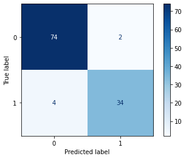

```python
plot_confusion_matrix(rfc, X_test, y_test, cmap='Blues')
```

```
<sklearn.metrics._plot.precision_recall_curve.PrecisionRecallDisplay at 0x1d573b1c0c8>
```

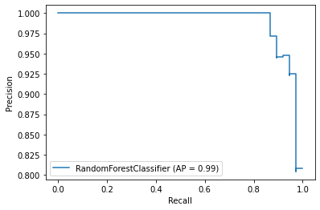

```python
plot_precision_recall_curve(rfc, X_test, y_test)
```

```
<sklearn.metrics._plot.roc_curve.RocCurveDisplay at 0x1d573b84b88>
```

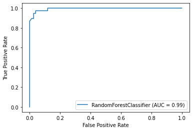

```python
plot_roc_curve(rfc, X_test, y_test)
```

```python
y_score = rfc.predict_proba(X_test)

round(roc_auc_score(y_test, y_score[:, 1]),2)
```

```
0.99
```